# Group 12 Project (R-dplyr-mgcv version)

Jingwen(Alex) Xiao

2019/12/11

First read data and import packages.

```r
library(SASxport)
library(dplyr)
library(mgcv)
library(tidyr)
```

```r
library(ggplot2)
library(kableExtra)
alc = read.xport("C:/Users/Surface-pc/Downloads/ALQ_D.xpt")
phy = read.xport("C:/Users/Surface-pc/Downloads/PAQ_D.xpt")
phy_id = read.xport("C:/Users/Surface-pc/Downloads/PAQIAF_D.xpt")
slp = read.xport("C:/Users/Surface-pc/Downloads/SLQ_D.xpt")
demo = read.xport("C:/Users/Surface-pc/Downloads/DEMO_D.xpt")
total_d1 = read.xport("C:/Users/Surface-pc/Downloads/DR1TOT_D.xpt")
```

Select variables that might be of interest.

```r
alc = alc %>% transmute(seqn = SEQN, alcohol = ALQ130)
phy = phy %>% transmute(seqn = SEQN, pa_comp = PAQ520)
phy_id = phy_id %>% transmute(seqn = SEQN, pa_time = PADTIMES, pa_dur = PADDURAT)
slp = slp %>% transmute(seqn = SEQN, sleep = SLD010H)
demo = demo %>% transmute(seqn = SEQN, gender = RIAGENDR, age = RIDAGEYR,
                          race = RIDRETH1, inc = INDFMINC, winter = RIDEXMON)
total_d1 = total_d1 %>% transmute(seqn = SEQN, energy_1 = DR1TKCAL,
                                  sugar_1 = DR1TSUGR, caffe_1 = DR1TCAFF)
```

Day 2 data is currently dropped to get more complete observations. Currently $n = 1769$.

Merge dataframes and recode factor variables. An uncoded version is available in the second following chunk.

```r
data = left_join(demo, alc, by="seqn") %>% left_join(phy_id, by="seqn") %>%
       left_join(phy, by = "seqn") %>% left_join(total_d1, "seqn") %>%
       left_join(slp, "seqn")
```

Before moving on, we perform a quick check on the number of missing values in each variable to get a better view of the current dataset.

```r
colSums(apply(data, 2, is.na))
```

```
##     seqn   gender      age     race      inc   winter  alcohol  pa_time
##        0        0        0        0      166      649    13606     5457
##   pa_dur  pa_comp energy_1  sugar_1  caffe_1    sleep
##     5453     3197     1691     1691     1691     6608
```

Results of this part is available in the data description. Now we recode some of the variables and get rid of observations with numeric codes representing “refuse” or “don’t know”. Another version with no factor recode is shown in the second chunk.

```r
data = data %>% filter(!is.na(sleep), pa_comp%in%c(1, 2, 3),
         alcohol!=999, sleep<77, inc<12) %>% mutate(gender = ifelse(gender==1, 1, 0),
         Mex = ifelse(race == 1, 1, 0), Hisp = ifelse(race == 2, 1, 0),
         NHwhite = ifelse(race == 3, 1, 0), NHblack = ifelse(race == 4, 1, 0),
         pa_high = ifelse(pa_comp == 1, 1, 0), pa_low = ifelse(pa_comp == 2, 1, 0),
         winter = ifelse(winter == 1, 1, 0), pad = pa_time*pa_dur/60) %>%
       select(-c("race","pa_comp", "pa_time", "pa_dur"))
```

```r
data1 = left_join(demo, alc, by="seqn") %>% left_join(phy_id, by="seqn") %>%
  left_join(phy, by = "seqn") %>% left_join(total_d1, "seqn") %>%
  left_join(slp, "seqn") %>% filter(!is.na(sleep), pa_comp%in%c(1, 2, 3),
            alcohol!=999, sleep<77, inc<12) %>% mutate(gender = ifelse(gender==1, 1, 0),
            winter = ifelse(winter == 1, 1, 0), pad = pa_time*pa_dur/60) %>%
  select(-c("pa_time", "pa_dur"))
```

Now remove incomplete observaions.

```r
dat = data[complete.cases(data),] %>% group_by(seqn) %>%
      mutate(pad = mean(pad)) %>% distinct()
dat1 = data1[complete.cases(data1),] %>% group_by(seqn) %>%
       mutate(pad = mean(pad)) %>% distinct()
```

For the analysis part, it is always a nice choice to first perform an OLS. The $R^2$ of this model is around 0.0576, with an adjusted $R^2$ of about 0.0495.

```r
result0=lm(sleep~as.factor(gender) + age + inc + as.factor(winter) +
             alcohol + energy_1 + sugar_1 + caffe_1 + as.factor(Mex) + as.factor(Hisp) +
             as.factor(NHwhite) + as.factor(NHblack) + as.factor(pa_high) +
             as.factor(pa_low) + pad, data=dat)
summary(result0)
```

```
##
## Call:
## lm(formula = sleep ~ as.factor(gender) + age + inc + as.factor(winter) +
##     alcohol + energy_1 + sugar_1 + caffe_1 + as.factor(Mex) +
##     as.factor(Hisp) + as.factor(NHwhite) + as.factor(NHblack) +
##     as.factor(pa_high) + as.factor(pa_low) + pad, data = dat)
##
## Residuals:
## How much sleep do you get (hours)?
##     Min      1Q  Median      3Q     Max
## -5.8739 -0.7984 -0.0088  0.8815  5.2858
##
## Coefficients:
##                       Estimate Std. Error t value Pr(>|t|)
## (Intercept)          6.873e+00  2.105e-01  32.657   <2e-16 ***
## as.factor(gender)1  -3.801e-02  6.655e-02  -0.571   0.5679
## age                  3.362e-03  1.970e-03   1.707   0.0881 .
## inc                 -1.390e-02  1.058e-02  -1.314   0.1890
## as.factor(winter)1   5.067e-02  6.239e-02   0.812   0.4168
## alcohol             -3.286e-02  1.295e-02  -2.538   0.0112 *
## energy_1             1.783e-05  3.844e-05   0.464   0.6428
## sugar_1             -7.512e-04  4.660e-04  -1.612   0.1072
## caffe_1             -7.169e-04  1.530e-04  -4.686    3e-06 ***
## as.factor(Mex)1      2.460e-01  1.737e-01   1.416   0.1568
## as.factor(Hisp)1    -1.045e-03  2.230e-01  -0.005   0.9963
## as.factor(NHwhite)1  3.985e-01  1.582e-01   2.519   0.0119 *
## as.factor(NHblack)1 -2.751e-01  1.689e-01  -1.629   0.1036
## as.factor(pa_high)1  3.466e-02  6.658e-02   0.521   0.6027
## as.factor(pa_low)1   1.494e-01  8.475e-02   1.763   0.0781 .
## pad                 -3.769e-03  1.999e-03  -1.885   0.0596 .
## ---
## Signif. codes:  0 '***' 0.001 '**' 0.01 '*' 0.05 '.' 0.1 ' ' 1
##
## Residual standard error: 1.227 on 1753 degrees of freedom
## Multiple R-squared:  0.05755,    Adjusted R-squared:  0.04949
## F-statistic: 7.137 on 15 and 1753 DF,  p-value: 1.995e-15
```

Next fit a GAM on both processed data sets. The total deviation explained is 8.26%, obviously better than the OLS result. Adjusted $R^2$ dropped a little (~0.07) when factor variables are not recoded, so the recoded version will be kept in later versions.

```r
result=gam(sleep~as.factor(Mex)+as.factor(NHwhite)+as.factor(NHblack)+
           as.factor(pa_low)+s(age)+s(alcohol)+s(pad)+
           s(energy_1)+s(sugar_1)+s(caffe_1),data=dat)
summary(result)
```

```
##
## Family: gaussian
## Link function: identity
##
## Formula:
## sleep ~ as.factor(Mex) + as.factor(NHwhite) + as.factor(NHblack) +
##     as.factor(pa_low) + s(age) + s(alcohol) + s(pad) + s(energy_1) +
##     s(sugar_1) + s(caffe_1)
##
## Parametric coefficients:
##                     Estimate Std. Error t value Pr(>|t|)
## (Intercept)          6.60913    0.11179  59.119  < 2e-16 ***
## as.factor(Mex)1      0.29626    0.13558   2.185 0.029011 *
## as.factor(NHwhite)1  0.39930    0.11761   3.395 0.000701 ***
## as.factor(NHblack)1 -0.20959    0.13152  -1.594 0.111218
## as.factor(pa_low)1   0.15782    0.07813   2.020 0.043547 *
## ---
## Signif. codes:  0 '***' 0.001 '**' 0.01 '*' 0.05 '.' 0.1 ' ' 1
##
## Approximate significance of smooth terms:
##               edf Ref.df      F  p-value
## s(age)      4.769  5.826  4.229 0.000366 ***
## s(alcohol)  1.000  1.000  9.366 0.002243 **
## s(pad)      4.525  5.542  1.617 0.134570
## s(energy_1) 1.921  2.457  1.578 0.196664
## s(sugar_1)  4.681  5.765  2.800 0.009681 **
## s(caffe_1)  1.000  1.000 14.492 0.000145 ***
## ---
## Signif. codes:  0 '***' 0.001 '**' 0.01 '*' 0.05 '.' 0.1 ' ' 1
##
## R-sq.(adj) =  0.0711   Deviance explained = 8.26%
## GCV = 1.4908  Scale est. = 1.4715    n = 1769
```

```r
result1=gam(sleep~as.factor(race)+as.factor(pa_comp)+
            s(age)+s(alcohol)+s(pad)+s(energy_1)+s(sugar_1)+
            s(caffe_1),data=dat1)
summary(result1)
```

```
##
## Family: gaussian
## Link function: identity
##
## Formula:
## sleep ~ as.factor(race) + as.factor(pa_comp) + s(age) + s(alcohol) +
##     s(pad) + s(energy_1) + s(sugar_1) + s(caffe_1)
##
## Parametric coefficients:
##                     Estimate Std. Error t value Pr(>|t|)
## (Intercept)          6.91413    0.08610  80.303  < 2e-16 ***
## as.factor(race)2    -0.30582    0.17944  -1.704   0.0885 .
## as.factor(race)3     0.10259    0.08786   1.168   0.2431
## as.factor(race)4    -0.50703    0.10494  -4.832 1.47e-06 ***
## as.factor(race)5    -0.28958    0.17087  -1.695   0.0903 .
## as.factor(pa_comp)2  0.14857    0.08587   1.730   0.0838 .
## as.factor(pa_comp)3 -0.01677    0.06611  -0.254   0.7998
## ---
## Signif. codes:  0 '***' 0.001 '**' 0.01 '*' 0.05 '.' 0.1 ' ' 1
##
## Approximate significance of smooth terms:
##               edf Ref.df      F  p-value
## s(age)      4.753  5.808  4.191 0.000411 ***
## s(alcohol)  1.000  1.000  9.323 0.002296 **
## s(pad)      4.480  5.491  1.623 0.133989
## s(energy_1) 1.918  2.453  1.535 0.206188
## s(sugar_1)  4.682  5.767  2.790 0.009908 **
## s(caffe_1)  1.000  1.000 14.521 0.000143 ***
## ---
## Signif. codes:  0 '***' 0.001 '**' 0.01 '*' 0.05 '.' 0.1 ' ' 1
##
## R-sq.(adj) =   0.07   Deviance explained = 8.26%
## GCV = 1.4942  Scale est. = 1.4732    n = 1769
```

To have a look on the effect of variable **pad**, we use spline regression for this term only. The output plot shows a straight line and is strongly affected by two points with extreme **pad** values.

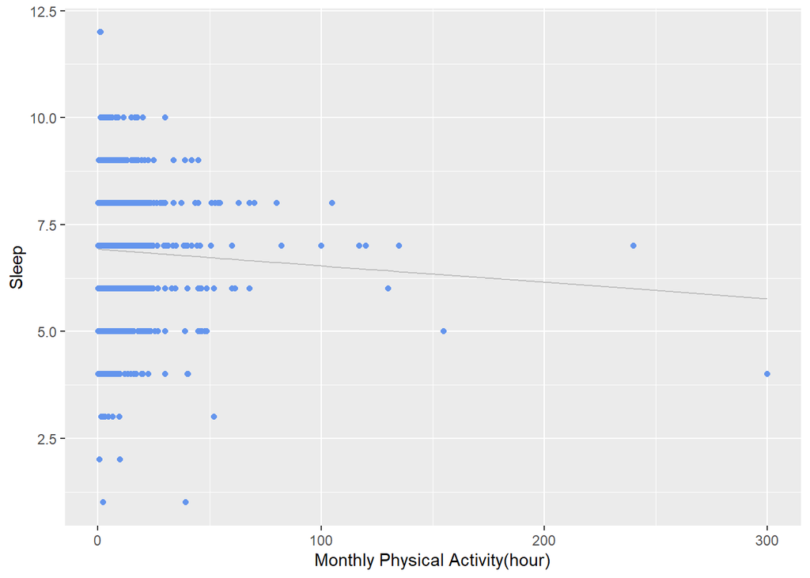

```r
res_pad = gam(sleep ~ s(pad), data = dat)
df = data.frame(x = dat$pad, y=dat$sleep, z=fitted(res_pad))
ggplot(df) + geom_point(aes(x = x, y = y), col="cornflowerblue") +
  geom_line(aes(x = x, y = z),col = "gray") +
  labs(x = "Monthly Physical Activity(hour)", y = "Sleep")
```

Now we discard the two large points. We somehow got a curvature in the plot, but the discrepancy is not very much convincing.

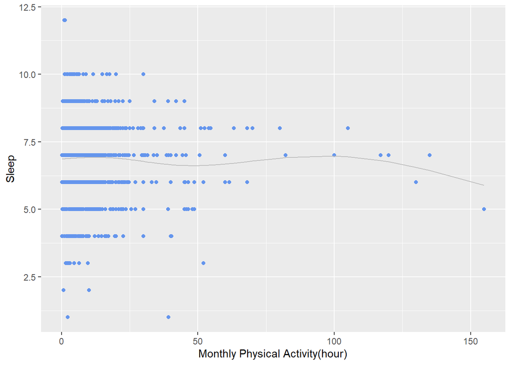

```r
dat2 = as.data.frame(dat[dat$pad<200, ])
res_pad1 = gam(sleep~s(pad), data = dat2)
df1 = data.frame(x = dat2$pad, y = dat2$sleep, z = fitted(res_pad1))
ggplot(df1) + geom_point(aes(x = x, y = y), col = "cornflowerblue") +
  geom_line(aes(x = x, y = z), col = "gray") +
  labs(x = "Monthly Physical Activity(hour)", y = "Sleep")
```

Since there could be a difference between the complete observations and incomplete observations, we perform the same actions on the full dataset, only dropping observations with missing values on **pad** and **sleep**. However, since we witnessed only a slight downward trend in this part of data, it seems that the response itself is somewhat random.

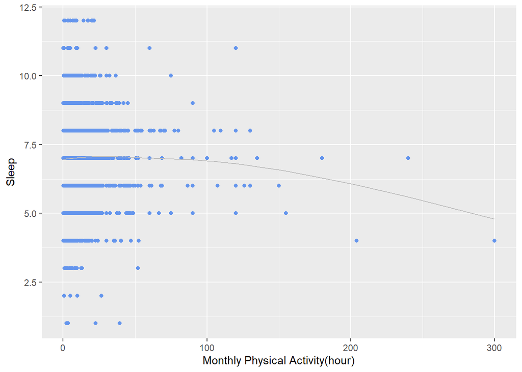

```r
data_pad = left_join(slp, phy, by="seqn") %>%
  left_join(phy_id, by="seqn") %>% filter(!is.na(sleep), sleep<77) %>%
  mutate(pad = pa_time*pa_dur/60) %>% select(-c("pa_time", "pa_dur"))

data_pad = data_pad%>%filter(rowSums(apply(data_pad,2,is.na))==0) %>% select(-"pa_comp")%>%
  group_by(seqn) %>% mutate(pad = mean(pad)) %>% distinct()

res_pad2 = gam(sleep~s(pad), data = data_pad)
df2 = data.frame(x = data_pad$pad, y = data_pad$sleep, z = fitted(res_pad2))
ggplot(df2) + geom_point(aes(x = x, y = y), col = "cornflowerblue") +
  geom_line(aes(x = x, y =z ), col = "gray") +
  labs(x = "Monthly Physical Activity(hour)", y = "Sleep")
```

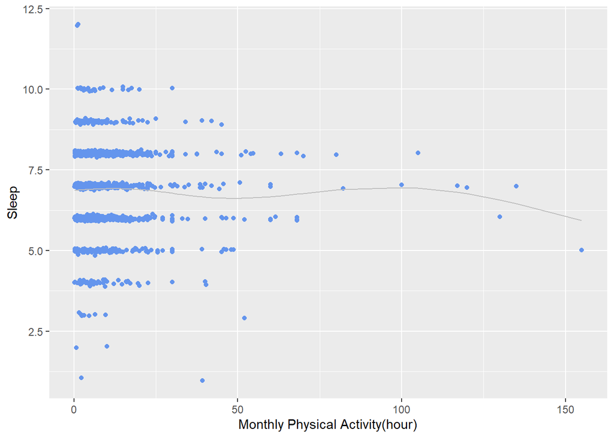

```r
eps=rnorm(nrow(dat2), 0, 0.04)
dat_eps = as.data.frame(dat[dat$pad<200, ])
dat_eps = dat_eps %>% mutate(sleep = as.numeric(sleep)+eps)
res_eps_pad = gam(sleep~s(pad), data = dat_eps)
df_eps = data.frame(x=dat_eps$pad,y=dat_eps$sleep, z=fitted(res_eps_pad))
ggplot(df_eps) + geom_point(aes(x=x,y=y),col="cornflowerblue") +
  geom_line(aes(x=x,y=z),col="gray") +
  labs(x = "Monthly Physical Activity(hour)", y = "Sleep")
```

For comparison, consider OLS and polynomials of power 2 and 3. Though no model is reporting a significant contribution from **pad**, it seems that the spline model is still doing better.

```r
ols_eps = lm(sleep~pad, dat_eps)
summary(ols_eps)
```

```
##
## Call:
## lm(formula = sleep ~ pad, data = dat_eps)
##
## Residuals:
##     Min      1Q  Median      3Q     Max
## -5.8504 -0.8866  0.1035  1.0936  5.1035
##
## Coefficients:
##              Estimate Std. Error t value Pr(>|t|)
## (Intercept)  6.910011   0.037422 184.650   <2e-16 ***
## pad         -0.002803   0.002491  -1.125    0.261
## ---
## Signif. codes:  0 '***' 0.001 '**' 0.01 '*' 0.05 '.' 0.1 ' ' 1
##
## Residual standard error: 1.259 on 1765 degrees of freedom
## Multiple R-squared:  0.0007166,  Adjusted R-squared:  0.0001504
## F-statistic: 1.266 on 1 and 1765 DF,  p-value: 0.2607
```

```r
poly_eps2 = lm(sleep~poly(pad, 2),dat_eps)
summary(poly_eps2)
```

```
##
## Call:
## lm(formula = sleep ~ poly(pad, 2), data = dat_eps)
##
## Residuals:
##     Min      1Q  Median      3Q     Max
## -5.8581 -0.8868  0.1048  1.0941  5.1113
##
## Coefficients:
##               Estimate Std. Error t value Pr(>|t|)
## (Intercept)    6.88476    0.02995 229.866   <2e-16 ***
## poly(pad, 2)1 -1.41610    1.25902  -1.125    0.261
## poly(pad, 2)2 -0.48306    1.25902  -0.384    0.701
## ---
## Signif. codes:  0 '***' 0.001 '**' 0.01 '*' 0.05 '.' 0.1 ' ' 1
##
## Residual standard error: 1.259 on 1764 degrees of freedom
## Multiple R-squared:  0.0008, Adjusted R-squared:  -0.0003329
## F-statistic: 0.7062 on 2 and 1764 DF,  p-value: 0.4937
```

```r
poly_eps3 = lm(sleep~poly(pad,3),dat_eps)
summary(poly_eps3)
```

```
##
## Call:
## lm(formula = sleep ~ poly(pad, 3), data = dat_eps)
##
## Residuals:
##     Min      1Q  Median      3Q     Max
## -5.8604 -0.8865  0.1047  1.0939  5.1092
##
## Coefficients:
##               Estimate Std. Error t value Pr(>|t|)
## (Intercept)    6.88476    0.02996 229.802   <2e-16 ***
## poly(pad, 3)1 -1.41610    1.25937  -1.124    0.261
## poly(pad, 3)2 -0.48306    1.25937  -0.384    0.701
## poly(pad, 3)3 -0.12892    1.25937  -0.102    0.918
## ---
## Signif. codes:  0 '***' 0.001 '**' 0.01 '*' 0.05 '.' 0.1 ' ' 1
##
## Residual standard error: 1.259 on 1763 degrees of freedom
## Multiple R-squared:  0.0008059,  Adjusted R-squared:  -0.0008943
## F-statistic: 0.474 on 3 and 1763 DF,  p-value: 0.7004
```

To have a closer look on the effects, we perform 10-fold cross validation and RMSE calculation with these four models. Unfortunately, spline method is not performing well in the CV part.

```r
N = nrow(dat_eps)
ind = rep(1:10, N%/%10+1)[1:N]
r_ind=sample(ind, N, F)
mat_rmse=matrix(0,10,4)
for (i in 1:10){
  train = dat_eps[r_ind!=i, ]
  test = dat_eps[r_ind==i, ]
  test_x=test%>%select(-"sleep")
  test_y=test[,"sleep"]
  ols_train = lm(sleep~pad, data = train)
  ols_test=predict(ols_train,test_x)
  p2_train = lm(sleep~poly(pad,2), data = train)
  p2_test=predict(p2_train,test_x)
  p3_train = lm(sleep~poly(pad,3), data = train)
  p3_test=predict(p3_train,test_x)
  gam_train = gam(sleep~s(pad), data = train)
  gam_test=predict(gam_train,test_x)
  mat_rmse[i,1]=sqrt(mean((test_y-ols_test)^2))
  mat_rmse[i,2]=sqrt(mean((test_y-p2_test)^2))
  mat_rmse[i,3]=sqrt(mean((test_y-p3_test)^2))
  mat_rmse[i,4]=sqrt(mean((test_y-gam_test)^2))
}
```

```r
names = c('OLS', 'Polynomial(2)', 'Polynomial(3)', 'Spline/GAM')
CV = colMeans(mat_rmse)
cap_title1 = '**Table 1.** *Cross-validation Results of Different Models.*'
cols = c('OLS','Polynomial(2)','Polynomial(3)','Spline/GAM')
kable(t(CV), digits = 4, caption = cap_title1, col.names = cols, align = 'c')%>%
      kable_styling("striped", position = "center")
```

**Table 1.** *Cross-validation Results of Different Models.*

| OLS | Polynomial(2) | Polynomial(3) | Spline/GAM |
| --- | --- | --- | --- |
| 1.256 | 1.2563 | 1.2587 | 1.2571 |

However, spline method is slightly better in RMSE than others when using the whole dataset.

```r
rmse = function(method){
 round(sqrt(mean(method$residual^2)),5)
}
rmse_ols = rmse(ols_eps)
rmse_poly2 = rmse(poly_eps2)
rmse_poly3 = rmse(poly_eps3)
rmse_gam = rmse(res_eps_pad)
RMSE =c(rmse_ols, rmse_poly2, rmse_poly3, rmse_gam)
cap_title2 = '**Table 2.** *Full-data RMSE Results of Different Models.*'
kable(t(RMSE), digits = 4, caption = cap_title2, col.names = cols, align = 'c')%>%
  kable_styling("striped", position = "center")
```

**Table 2.** *Full-data RMSE Results of Different Models.*

| OLS | Polynomial(2) | Polynomial(3) | Spline/GAM |
| --- | --- | --- | --- |
| 1.258 | 1.2579 | 1.2579 | 1.2561 |

To this point, we have to re-think whether physical activity really have a discriminative effect on the sleep time. In fact, the sleep time that people need is rather random, and the contribution from other factors are somewhat minor.